# Risk Factor Analysis

## Outcome Variable

**Outcome Variable:** ever_co

## Predictor Variables

**Intervention Variable:** nchldlt5

**Adjustment Set:**

unadjusted

## Stratifying Variables

The analysis was stratified on these variable(s):

- agecat
- studyid
- country

## Data Summary

| agecat | studyid | country | nchldlt5 | ever_co | n_cell | n |
| --- | --- | --- | --- | --- | --- | --- |
| 0-24 months | iLiNS-Zinc | BURKINA FASO | 1 | 0 | 956 | 3188 |
| 0-24 months | iLiNS-Zinc | BURKINA FASO | 1 | 1 | 117 | 3188 |
| 0-24 months | iLiNS-Zinc | BURKINA FASO | 2+ | 0 | 1849 | 3188 |
| 0-24 months | iLiNS-Zinc | BURKINA FASO | 2+ | 1 | 266 | 3188 |
| 0-24 months | IRC | INDIA | 1 | 0 | 69 | 410 |
| 0-24 months | IRC | INDIA | 1 | 1 | 20 | 410 |
| 0-24 months | IRC | INDIA | 2+ | 0 | 265 | 410 |
| 0-24 months | IRC | INDIA | 2+ | 1 | 56 | 410 |
| 0-24 months | LCNI-5 | MALAWI | 1 | 0 | 376 | 812 |
| 0-24 months | LCNI-5 | MALAWI | 1 | 1 | 15 | 812 |
| 0-24 months | LCNI-5 | MALAWI | 2+ | 0 | 394 | 812 |
| 0-24 months | LCNI-5 | MALAWI | 2+ | 1 | 27 | 812 |
| 0-24 months | NIH-Crypto | BANGLADESH | 1 | 0 | 496 | 758 |
| 0-24 months | NIH-Crypto | BANGLADESH | 1 | 1 | 45 | 758 |
| 0-24 months | NIH-Crypto | BANGLADESH | 2+ | 0 | 191 | 758 |
| 0-24 months | NIH-Crypto | BANGLADESH | 2+ | 1 | 26 | 758 |
| 0-24 months | PROVIDE | BANGLADESH | 1 | 0 | 447 | 700 |
| 0-24 months | PROVIDE | BANGLADESH | 1 | 1 | 65 | 700 |
| 0-24 months | PROVIDE | BANGLADESH | 2+ | 0 | 163 | 700 |
| 0-24 months | PROVIDE | BANGLADESH | 2+ | 1 | 25 | 700 |
| 0-24 months | TanzaniaChild2 | TANZANIA, UNITED REPUBLIC OF | 1 | 0 | 1552 | 2385 |
| 0-24 months | TanzaniaChild2 | TANZANIA, UNITED REPUBLIC OF | 1 | 1 | 85 | 2385 |
| 0-24 months | TanzaniaChild2 | TANZANIA, UNITED REPUBLIC OF | 2+ | 0 | 714 | 2385 |
| 0-24 months | TanzaniaChild2 | TANZANIA, UNITED REPUBLIC OF | 2+ | 1 | 34 | 2385 |
| 0-6 months | IRC | INDIA | 1 | 0 | 79 | 409 |
| 0-6 months | IRC | INDIA | 1 | 1 | 10 | 409 |
| 0-6 months | IRC | INDIA | 2+ | 0 | 305 | 409 |
| 0-6 months | IRC | INDIA | 2+ | 1 | 15 | 409 |
| 0-6 months | LCNI-5 | MALAWI | 1 | 0 | 122 | 267 |
| 0-6 months | LCNI-5 | MALAWI | 1 | 1 | 0 | 267 |
| 0-6 months | LCNI-5 | MALAWI | 2+ | 0 | 145 | 267 |
| 0-6 months | LCNI-5 | MALAWI | 2+ | 1 | 0 | 267 |
| 0-6 months | NIH-Crypto | BANGLADESH | 1 | 0 | 531 | 758 |
| 0-6 months | NIH-Crypto | BANGLADESH | 1 | 1 | 10 | 758 |
| 0-6 months | NIH-Crypto | BANGLADESH | 2+ | 0 | 210 | 758 |
| 0-6 months | NIH-Crypto | BANGLADESH | 2+ | 1 | 7 | 758 |
| 0-6 months | PROVIDE | BANGLADESH | 1 | 0 | 491 | 700 |
| 0-6 months | PROVIDE | BANGLADESH | 1 | 1 | 21 | 700 |
| 0-6 months | PROVIDE | BANGLADESH | 2+ | 0 | 179 | 700 |
| 0-6 months | PROVIDE | BANGLADESH | 2+ | 1 | 9 | 700 |
| 0-6 months | TanzaniaChild2 | TANZANIA, UNITED REPUBLIC OF | 1 | 0 | 1622 | 2385 |
| 0-6 months | TanzaniaChild2 | TANZANIA, UNITED REPUBLIC OF | 1 | 1 | 15 | 2385 |
| 0-6 months | TanzaniaChild2 | TANZANIA, UNITED REPUBLIC OF | 2+ | 0 | 744 | 2385 |
| 0-6 months | TanzaniaChild2 | TANZANIA, UNITED REPUBLIC OF | 2+ | 1 | 4 | 2385 |
| 6-24 months | iLiNS-Zinc | BURKINA FASO | 1 | 0 | 956 | 3188 |
| 6-24 months | iLiNS-Zinc | BURKINA FASO | 1 | 1 | 117 | 3188 |
| 6-24 months | iLiNS-Zinc | BURKINA FASO | 2+ | 0 | 1849 | 3188 |
| 6-24 months | iLiNS-Zinc | BURKINA FASO | 2+ | 1 | 266 | 3188 |
| 6-24 months | IRC | INDIA | 1 | 0 | 73 | 410 |
| 6-24 months | IRC | INDIA | 1 | 1 | 16 | 410 |
| 6-24 months | IRC | INDIA | 2+ | 0 | 273 | 410 |
| 6-24 months | IRC | INDIA | 2+ | 1 | 48 | 410 |
| 6-24 months | LCNI-5 | MALAWI | 1 | 0 | 369 | 800 |
| 6-24 months | LCNI-5 | MALAWI | 1 | 1 | 15 | 800 |
| 6-24 months | LCNI-5 | MALAWI | 2+ | 0 | 389 | 800 |
| 6-24 months | LCNI-5 | MALAWI | 2+ | 1 | 27 | 800 |
| 6-24 months | NIH-Crypto | BANGLADESH | 1 | 0 | 481 | 730 |
| 6-24 months | NIH-Crypto | BANGLADESH | 1 | 1 | 39 | 730 |
| 6-24 months | NIH-Crypto | BANGLADESH | 2+ | 0 | 186 | 730 |
| 6-24 months | NIH-Crypto | BANGLADESH | 2+ | 1 | 24 | 730 |
| 6-24 months | PROVIDE | BANGLADESH | 1 | 0 | 396 | 614 |
| 6-24 months | PROVIDE | BANGLADESH | 1 | 1 | 52 | 614 |
| 6-24 months | PROVIDE | BANGLADESH | 2+ | 0 | 143 | 614 |
| 6-24 months | PROVIDE | BANGLADESH | 2+ | 1 | 23 | 614 |
| 6-24 months | TanzaniaChild2 | TANZANIA, UNITED REPUBLIC OF | 1 | 0 | 1303 | 2009 |
| 6-24 months | TanzaniaChild2 | TANZANIA, UNITED REPUBLIC OF | 1 | 1 | 80 | 2009 |
| 6-24 months | TanzaniaChild2 | TANZANIA, UNITED REPUBLIC OF | 2+ | 0 | 593 | 2009 |
| 6-24 months | TanzaniaChild2 | TANZANIA, UNITED REPUBLIC OF | 2+ | 1 | 33 | 2009 |

The following strata were considered:

- agecat: 0-24 months, studyid: iLiNS-Zinc, country: BURKINA FASO
- agecat: 0-24 months, studyid: IRC, country: INDIA
- agecat: 0-24 months, studyid: LCNI-5, country: MALAWI
- agecat: 0-24 months, studyid: NIH-Crypto, country: BANGLADESH
- agecat: 0-24 months, studyid: PROVIDE, country: BANGLADESH
- agecat: 0-24 months, studyid: TanzaniaChild2, country: TANZANIA, UNITED REPUBLIC OF
- agecat: 0-6 months, studyid: IRC, country: INDIA
- agecat: 0-6 months, studyid: LCNI-5, country: MALAWI
- agecat: 0-6 months, studyid: NIH-Crypto, country: BANGLADESH
- agecat: 0-6 months, studyid: PROVIDE, country: BANGLADESH
- agecat: 0-6 months, studyid: TanzaniaChild2, country: TANZANIA, UNITED REPUBLIC OF
- agecat: 6-24 months, studyid: iLiNS-Zinc, country: BURKINA FASO
- agecat: 6-24 months, studyid: IRC, country: INDIA
- agecat: 6-24 months, studyid: LCNI-5, country: MALAWI
- agecat: 6-24 months, studyid: NIH-Crypto, country: BANGLADESH
- agecat: 6-24 months, studyid: PROVIDE, country: BANGLADESH
- agecat: 6-24 months, studyid: TanzaniaChild2, country: TANZANIA, UNITED REPUBLIC OF

### Dropped Strata

Some strata were dropped due to rare outcomes:

- agecat: 0-6 months, studyid: LCNI-5, country: MALAWI
- agecat: 0-6 months, studyid: TanzaniaChild2, country: TANZANIA, UNITED REPUBLIC OF

## Methods Detail

We’re interested in the causal parameters $E[Y_a]$ for all values of $a \in \mathcal{A}$. These parameters represent the mean outcome if, possibly contrary to fact, we intervened to set all units to have $A=a$. Under the randomization and positivity assumptions, these are identified by the statistical parameters $\psi_a=E_W[E_{Y|A,W}(Y|A=a,W)]$. In addition, we’re interested in the mean of $Y$, $E[Y]$ under no intervention (the observed mean). We will estimate these parameters by using SuperLearner to fit the relevant likelihood factors – $E_{Y|A,W}(Y|A=a,W)$ and $p(A=a|W)$, and then updating our likelihood fit using a joint TMLE.

For unadjusted analyses ($W=\{\}$), initial likelihoods were estimated using Lrnr_glm to estimate the simple $E(Y|A)$ and Lrnr_mean to estimate $p(A)$. For adjusted analyses, a small library containing Lrnr_glmnet, Lrnr_xgboost, and Lrnr_mean was used.

Having estimated these parameters, we will then use the delta method to estimate relative risks and attributable risks relative to a prespecified baseline level of $A$.

# Results Detail

## Results Plots

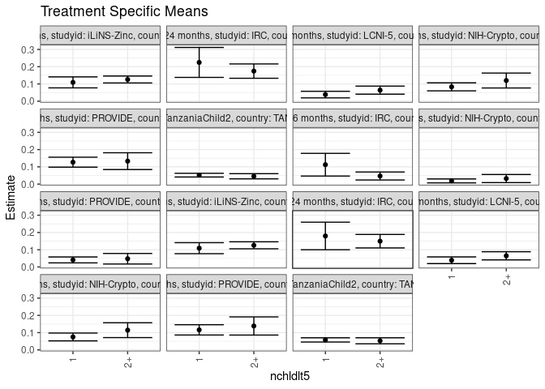

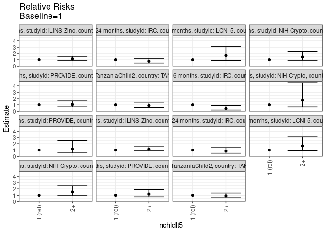

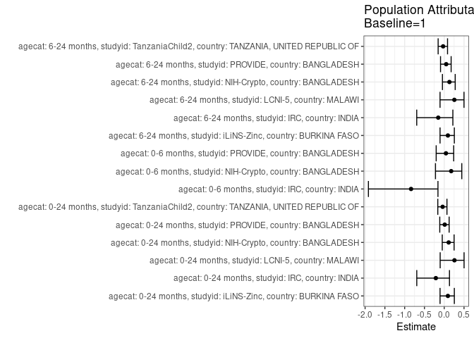

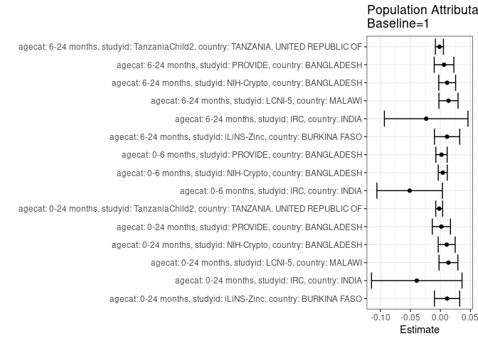

## Results Table

### Parameter: TSM

| agecat | studyid | country | intervention_level | baseline_level | estimate | ci_lower | ci_upper |
| --- | --- | --- | --- | --- | --- | --- | --- |
| 0-24 months | iLiNS-Zinc | BURKINA FASO | 1 | NA | 0.1090401 | 0.0771349 | 0.1409452 |
| 0-24 months | iLiNS-Zinc | BURKINA FASO | 2+ | NA | 0.1257683 | 0.1056249 | 0.1459117 |
| 0-24 months | IRC | INDIA | 1 | NA | 0.2247191 | 0.1378965 | 0.3115417 |
| 0-24 months | IRC | INDIA | 2+ | NA | 0.1744548 | 0.1328889 | 0.2160208 |
| 0-24 months | LCNI-5 | MALAWI | 1 | NA | 0.0383632 | 0.0193134 | 0.0574130 |
| 0-24 months | LCNI-5 | MALAWI | 2+ | NA | 0.0641330 | 0.0407165 | 0.0875495 |
| 0-24 months | NIH-Crypto | BANGLADESH | 1 | NA | 0.0831793 | 0.0598938 | 0.1064648 |
| 0-24 months | NIH-Crypto | BANGLADESH | 2+ | NA | 0.1198157 | 0.0765794 | 0.1630520 |
| 0-24 months | PROVIDE | BANGLADESH | 1 | NA | 0.1269531 | 0.0980953 | 0.1558110 |
| 0-24 months | PROVIDE | BANGLADESH | 2+ | NA | 0.1329787 | 0.0844068 | 0.1815507 |
| 0-24 months | TanzaniaChild2 | TANZANIA, UNITED REPUBLIC OF | 1 | NA | 0.0519243 | 0.0411739 | 0.0626746 |
| 0-24 months | TanzaniaChild2 | TANZANIA, UNITED REPUBLIC OF | 2+ | NA | 0.0454545 | 0.0305240 | 0.0603851 |
| 0-6 months | IRC | INDIA | 1 | NA | 0.1123596 | 0.0466682 | 0.1780509 |
| 0-6 months | IRC | INDIA | 2+ | NA | 0.0468750 | 0.0236877 | 0.0700623 |
| 0-6 months | NIH-Crypto | BANGLADESH | 1 | NA | 0.0184843 | 0.0071267 | 0.0298419 |
| 0-6 months | NIH-Crypto | BANGLADESH | 2+ | NA | 0.0322581 | 0.0087345 | 0.0557817 |
| 0-6 months | PROVIDE | BANGLADESH | 1 | NA | 0.0410156 | 0.0238245 | 0.0582067 |
| 0-6 months | PROVIDE | BANGLADESH | 2+ | NA | 0.0478723 | 0.0173323 | 0.0784124 |
| 6-24 months | iLiNS-Zinc | BURKINA FASO | 1 | NA | 0.1090401 | 0.0771349 | 0.1409452 |
| 6-24 months | iLiNS-Zinc | BURKINA FASO | 2+ | NA | 0.1257683 | 0.1056249 | 0.1459117 |
| 6-24 months | IRC | INDIA | 1 | NA | 0.1797753 | 0.0998996 | 0.2596510 |
| 6-24 months | IRC | INDIA | 2+ | NA | 0.1495327 | 0.1104736 | 0.1885919 |
| 6-24 months | LCNI-5 | MALAWI | 1 | NA | 0.0390625 | 0.0196723 | 0.0584527 |
| 6-24 months | LCNI-5 | MALAWI | 2+ | NA | 0.0649038 | 0.0412154 | 0.0885923 |
| 6-24 months | NIH-Crypto | BANGLADESH | 1 | NA | 0.0750000 | 0.0523460 | 0.0976540 |
| 6-24 months | NIH-Crypto | BANGLADESH | 2+ | NA | 0.1142857 | 0.0712252 | 0.1573462 |
| 6-24 months | PROVIDE | BANGLADESH | 1 | NA | 0.1160714 | 0.0863866 | 0.1457562 |
| 6-24 months | PROVIDE | BANGLADESH | 2+ | NA | 0.1385542 | 0.0859559 | 0.1911525 |
| 6-24 months | TanzaniaChild2 | TANZANIA, UNITED REPUBLIC OF | 1 | NA | 0.0578453 | 0.0455386 | 0.0701519 |
| 6-24 months | TanzaniaChild2 | TANZANIA, UNITED REPUBLIC OF | 2+ | NA | 0.0527157 | 0.0352059 | 0.0702254 |

### Parameter: E(Y)

| agecat | studyid | country | intervention_level | baseline_level | estimate | ci_lower | ci_upper |
| --- | --- | --- | --- | --- | --- | --- | --- |
| 0-24 months | iLiNS-Zinc | BURKINA FASO | NA | NA | 0.1201380 | 0.1003403 | 0.1399357 |
| 0-24 months | IRC | INDIA | NA | NA | 0.1853659 | 0.1477057 | 0.2230261 |
| 0-24 months | LCNI-5 | MALAWI | NA | NA | 0.0517241 | 0.0364818 | 0.0669665 |
| 0-24 months | NIH-Crypto | BANGLADESH | NA | NA | 0.0936675 | 0.0729118 | 0.1144233 |
| 0-24 months | PROVIDE | BANGLADESH | NA | NA | 0.1285714 | 0.1037574 | 0.1533855 |
| 0-24 months | TanzaniaChild2 | TANZANIA, UNITED REPUBLIC OF | NA | NA | 0.0498952 | 0.0411552 | 0.0586351 |
| 0-6 months | IRC | INDIA | NA | NA | 0.0611247 | 0.0378797 | 0.0843697 |
| 0-6 months | NIH-Crypto | BANGLADESH | NA | NA | 0.0224274 | 0.0118796 | 0.0329753 |
| 0-6 months | PROVIDE | BANGLADESH | NA | NA | 0.0428571 | 0.0278427 | 0.0578716 |
| 6-24 months | iLiNS-Zinc | BURKINA FASO | NA | NA | 0.1201380 | 0.1003403 | 0.1399357 |
| 6-24 months | IRC | INDIA | NA | NA | 0.1560976 | 0.1209228 | 0.1912723 |
| 6-24 months | LCNI-5 | MALAWI | NA | NA | 0.0525000 | 0.0370352 | 0.0679648 |
| 6-24 months | NIH-Crypto | BANGLADESH | NA | NA | 0.0863014 | 0.0659171 | 0.1066856 |
| 6-24 months | PROVIDE | BANGLADESH | NA | NA | 0.1221498 | 0.0962275 | 0.1480722 |
| 6-24 months | TanzaniaChild2 | TANZANIA, UNITED REPUBLIC OF | NA | NA | 0.0562469 | 0.0461696 | 0.0663242 |

### Parameter: RR

| agecat | studyid | country | intervention_level | baseline_level | estimate | ci_lower | ci_upper |
| --- | --- | --- | --- | --- | --- | --- | --- |
| 0-24 months | iLiNS-Zinc | BURKINA FASO | 1 | 1 | 1.0000000 | 1.0000000 | 1.0000000 |
| 0-24 months | iLiNS-Zinc | BURKINA FASO | 2+ | 1 | 1.1534138 | 0.8638414 | 1.5400549 |
| 0-24 months | IRC | INDIA | 1 | 1 | 1.0000000 | 1.0000000 | 1.0000000 |
| 0-24 months | IRC | INDIA | 2+ | 1 | 0.7763240 | 0.4930694 | 1.2223004 |
| 0-24 months | LCNI-5 | MALAWI | 1 | 1 | 1.0000000 | 1.0000000 | 1.0000000 |
| 0-24 months | LCNI-5 | MALAWI | 2+ | 1 | 1.6717340 | 0.9025850 | 3.0963228 |
| 0-24 months | NIH-Crypto | BANGLADESH | 1 | 1 | 1.0000000 | 1.0000000 | 1.0000000 |
| 0-24 months | NIH-Crypto | BANGLADESH | 2+ | 1 | 1.4404506 | 0.9123274 | 2.2742908 |
| 0-24 months | PROVIDE | BANGLADESH | 1 | 1 | 1.0000000 | 1.0000000 | 1.0000000 |
| 0-24 months | PROVIDE | BANGLADESH | 2+ | 1 | 1.0474632 | 0.6812370 | 1.6105688 |
| 0-24 months | TanzaniaChild2 | TANZANIA, UNITED REPUBLIC OF | 1 | 1 | 1.0000000 | 1.0000000 | 1.0000000 |
| 0-24 months | TanzaniaChild2 | TANZANIA, UNITED REPUBLIC OF | 2+ | 1 | 0.8754011 | 0.5937187 | 1.2907241 |
| 0-6 months | IRC | INDIA | 1 | 1 | 1.0000000 | 1.0000000 | 1.0000000 |
| 0-6 months | IRC | INDIA | 2+ | 1 | 0.4171875 | 0.1939686 | 0.8972865 |
| 0-6 months | NIH-Crypto | BANGLADESH | 1 | 1 | 1.0000000 | 1.0000000 | 1.0000000 |
| 0-6 months | NIH-Crypto | BANGLADESH | 2+ | 1 | 1.7451613 | 0.6725110 | 4.5286814 |
| 0-6 months | PROVIDE | BANGLADESH | 1 | 1 | 1.0000000 | 1.0000000 | 1.0000000 |
| 0-6 months | PROVIDE | BANGLADESH | 2+ | 1 | 1.1671733 | 0.5440406 | 2.5040289 |
| 6-24 months | iLiNS-Zinc | BURKINA FASO | 1 | 1 | 1.0000000 | 1.0000000 | 1.0000000 |
| 6-24 months | iLiNS-Zinc | BURKINA FASO | 2+ | 1 | 1.1534138 | 0.8638414 | 1.5400549 |
| 6-24 months | IRC | INDIA | 1 | 1 | 1.0000000 | 1.0000000 | 1.0000000 |
| 6-24 months | IRC | INDIA | 2+ | 1 | 0.8317757 | 0.4967864 | 1.3926524 |
| 6-24 months | LCNI-5 | MALAWI | 1 | 1 | 1.0000000 | 1.0000000 | 1.0000000 |
| 6-24 months | LCNI-5 | MALAWI | 2+ | 1 | 1.6615385 | 0.8972857 | 3.0767348 |
| 6-24 months | NIH-Crypto | BANGLADESH | 1 | 1 | 1.0000000 | 1.0000000 | 1.0000000 |
| 6-24 months | NIH-Crypto | BANGLADESH | 2+ | 1 | 1.5238095 | 0.9401710 | 2.4697585 |
| 6-24 months | PROVIDE | BANGLADESH | 1 | 1 | 1.0000000 | 1.0000000 | 1.0000000 |
| 6-24 months | PROVIDE | BANGLADESH | 2+ | 1 | 1.1936979 | 0.7552723 | 1.8866237 |
| 6-24 months | TanzaniaChild2 | TANZANIA, UNITED REPUBLIC OF | 1 | 1 | 1.0000000 | 1.0000000 | 1.0000000 |
| 6-24 months | TanzaniaChild2 | TANZANIA, UNITED REPUBLIC OF | 2+ | 1 | 0.9113219 | 0.6142782 | 1.3520056 |

### Parameter: PAR

| agecat | studyid | country | intervention_level | baseline_level | estimate | ci_lower | ci_upper |
| --- | --- | --- | --- | --- | --- | --- | --- |
| 0-24 months | iLiNS-Zinc | BURKINA FASO | 1 | NA | 0.0110979 | -0.0099759 | 0.0321717 |
| 0-24 months | IRC | INDIA | 1 | NA | -0.0393532 | -0.1147442 | 0.0360377 |
| 0-24 months | LCNI-5 | MALAWI | 1 | NA | 0.0133610 | -0.0023150 | 0.0290369 |
| 0-24 months | NIH-Crypto | BANGLADESH | 1 | NA | 0.0104882 | -0.0036198 | 0.0245963 |
| 0-24 months | PROVIDE | BANGLADESH | 1 | NA | 0.0016183 | -0.0135567 | 0.0167933 |
| 0-24 months | TanzaniaChild2 | TANZANIA, UNITED REPUBLIC OF | 1 | NA | -0.0020291 | -0.0078005 | 0.0037423 |
| 0-6 months | IRC | INDIA | 1 | NA | -0.0512349 | -0.1058023 | 0.0033326 |
| 0-6 months | NIH-Crypto | BANGLADESH | 1 | NA | 0.0039432 | -0.0035482 | 0.0114345 |
| 0-6 months | PROVIDE | BANGLADESH | 1 | NA | 0.0018415 | -0.0075736 | 0.0112566 |
| 6-24 months | iLiNS-Zinc | BURKINA FASO | 1 | NA | 0.0110979 | -0.0099759 | 0.0321717 |
| 6-24 months | IRC | INDIA | 1 | NA | -0.0236777 | -0.0933016 | 0.0459461 |
| 6-24 months | LCNI-5 | MALAWI | 1 | NA | 0.0134375 | -0.0025061 | 0.0293811 |
| 6-24 months | NIH-Crypto | BANGLADESH | 1 | NA | 0.0113014 | -0.0027550 | 0.0253577 |
| 6-24 months | PROVIDE | BANGLADESH | 1 | NA | 0.0060784 | -0.0102695 | 0.0224263 |
| 6-24 months | TanzaniaChild2 | TANZANIA, UNITED REPUBLIC OF | 1 | NA | -0.0015984 | -0.0082680 | 0.0050712 |

### Parameter: PAF

| agecat | studyid | country | intervention_level | baseline_level | estimate | ci_lower | ci_upper |
| --- | --- | --- | --- | --- | --- | --- | --- |
| 0-24 months | iLiNS-Zinc | BURKINA FASO | 1 | NA | 0.0923766 | -0.1059181 | 0.2551164 |
| 0-24 months | IRC | INDIA | 1 | NA | -0.2123004 | -0.6941184 | 0.1324855 |
| 0-24 months | LCNI-5 | MALAWI | 1 | NA | 0.2583120 | -0.1027103 | 0.5011373 |
| 0-24 months | NIH-Crypto | BANGLADESH | 1 | NA | 0.1119731 | -0.0501857 | 0.2490931 |
| 0-24 months | PROVIDE | BANGLADESH | 1 | NA | 0.0125868 | -0.1127648 | 0.1238177 |
| 0-24 months | TanzaniaChild2 | TANZANIA, UNITED REPUBLIC OF | 1 | NA | -0.0406667 | -0.1627920 | 0.0686320 |
| 0-6 months | IRC | INDIA | 1 | NA | -0.8382022 | -1.9162232 | -0.1586862 |
| 0-6 months | NIH-Crypto | BANGLADESH | 1 | NA | 0.1758182 | -0.2211410 | 0.4437370 |
| 0-6 months | PROVIDE | BANGLADESH | 1 | NA | 0.0429687 | -0.2033820 | 0.2388877 |
| 6-24 months | iLiNS-Zinc | BURKINA FASO | 1 | NA | 0.0923766 | -0.1059181 | 0.2551164 |
| 6-24 months | IRC | INDIA | 1 | NA | -0.1516854 | -0.6952935 | 0.2176108 |
| 6-24 months | LCNI-5 | MALAWI | 1 | NA | 0.2559524 | -0.1060520 | 0.4994748 |
| 6-24 months | NIH-Crypto | BANGLADESH | 1 | NA | 0.1309524 | -0.0452064 | 0.2774214 |
| 6-24 months | PROVIDE | BANGLADESH | 1 | NA | 0.0497619 | -0.0936031 | 0.1743326 |
| 6-24 months | TanzaniaChild2 | TANZANIA, UNITED REPUBLIC OF | 1 | NA | -0.0284171 | -0.1539935 | 0.0834941 |